# Combining

EE Holmes

## Introduction

Here is the intro.

## Tables

You can create nice html tables with R Markdown and they even look ok in Word. The main function I will show here is `kable()` with the kableExtra extensions. Read more on kableExtra [here](http://haozhu233.github.io/kableExtra/) and see many more examples.

Then you can make a basic table that looks ok in html, Word or PDF:

This is the table caption.

|  | mpg | cyl | disp | hp | drat | wt |
| --- | --- | --- | --- | --- | --- | --- |
| Mazda RX4 | 21.0 | 6 | 160 | 110 | 3.90 | 2.620 |
| Mazda RX4 Wag | 21.0 | 6 | 160 | 110 | 3.90 | 2.875 |
| Datsun 710 | 22.8 | 4 | 108 | 93 | 3.85 | 2.320 |
| Hornet 4 Drive | 21.4 | 6 | 258 | 110 | 3.08 | 3.215 |
| Hornet Sportabout | 18.7 | 8 | 360 | 175 | 3.15 | 3.440 |

If you would like fancy html tables, try the kableExtra package:

This will make a nice table if you knit to html but will not work in Word.

This is the table caption.

|  | mpg | cyl | disp | hp | drat | wt |
| --- | --- | --- | --- | --- | --- | --- |
| Mazda RX4 | 21.0 | 6 | 160 | 110 | 3.90 | 2.620 |
| Mazda RX4 Wag | 21.0 | 6 | 160 | 110 | 3.90 | 2.875 |
| Datsun 710 | 22.8 | 4 | 108 | 93 | 3.85 | 2.320 |
| Hornet 4 Drive | 21.4 | 6 | 258 | 110 | 3.08 | 3.215 |
| Hornet Sportabout | 18.7 | 8 | 360 | 175 | 3.15 | 3.440 |

You can easily create some nice effects for your tables in html and pdf documents like tables that float to the side. But table caption seems to hang in this case.

|  | mpg | cyl | disp | hp | drat | wt |
| --- | --- | --- | --- | --- | --- | --- |
| Mazda RX4 | 21.0 | 6 | 160 | 110 | 3.90 | 2.620 |
| Mazda RX4 Wag | 21.0 | 6 | 160 | 110 | 3.90 | 2.875 |
| Datsun 710 | 22.8 | 4 | 108 | 93 | 3.85 | 2.320 |
| Hornet 4 Drive | 21.4 | 6 | 258 | 110 | 3.08 | 3.215 |
| Hornet Sportabout | 18.7 | 8 | 360 | 175 | 3.15 | 3.440 |

You can also make tables in raw markdown but you are limited in what you can achieve. Read more about markdown table syntax [here](https://www.markdownguide.org/extended-syntax#tables).

| Tables | Are | Cool |
| --- | --- | --- |
| col 1 is | left-aligned | $1600 |
| col 2 is | centered | $12 |
| col 3 is | right-aligned | $1 |

## Figures

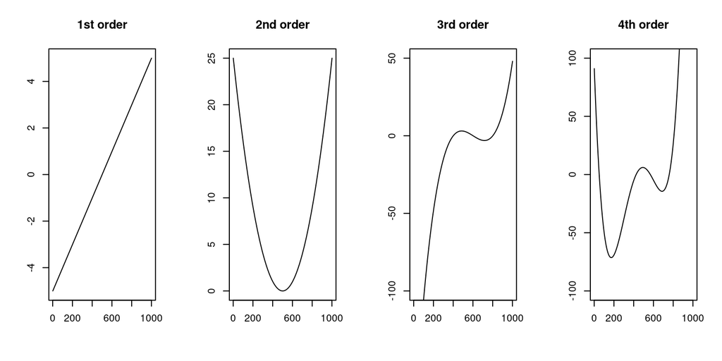

```r
par(mfrow=c(1,4))
tt <- seq(-5,5,.01)
plot(tt,type="l",ylab="",xlab="")
title("1st order")
plot(tt^2,type="l",ylab="",xlab="")
title("2nd order")
plot(tt^3-3*tt^2-tt+3,ylim=c(-100,50),type="l",ylab="",xlab="")
title("3rd order")
plot(tt^4+2*tt^3-12*tt^2-2*tt+6,ylim=c(-100,100),type="l",ylab="",xlab="")
title("4th order")
```

Specify `echo=FALSE` to hide the figure code. Set `message=FALSE` and `warning=FALSE` to suppress package loading messages.

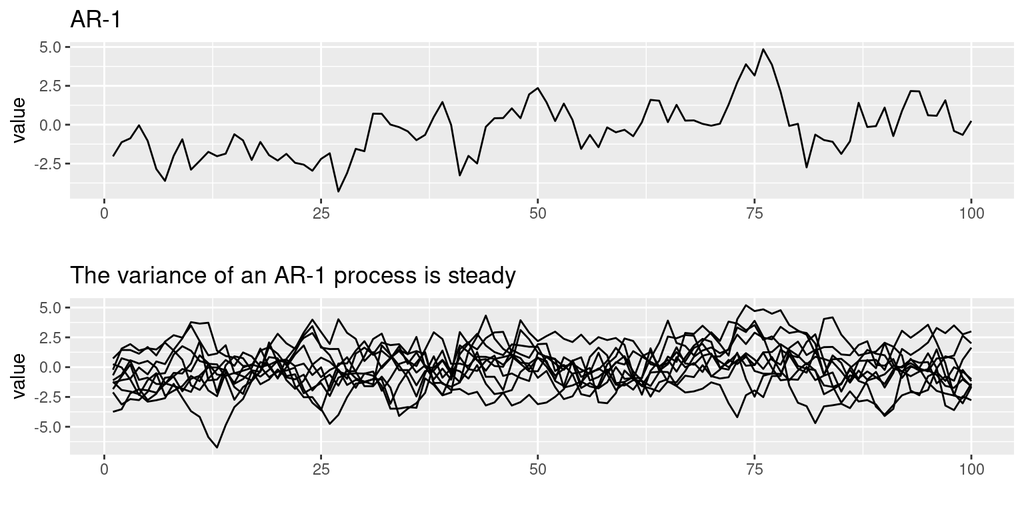

You can include figure legends if your yaml has

```
output:
  html_document:
    fig_caption: yes
```

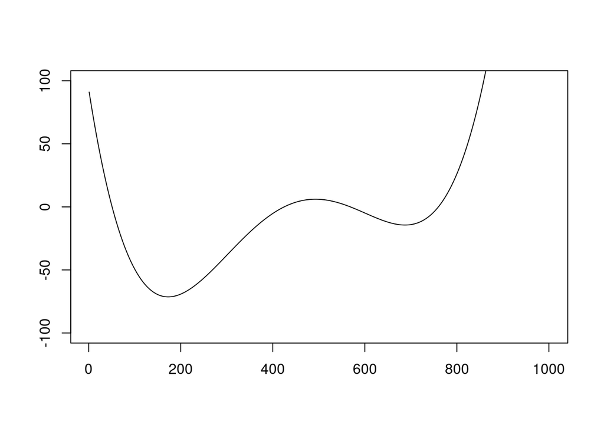

Here is a 4th order polynomial.